# R Notebook

# Statistics VIII Homework Ch16_Textbook

## 16.83

### a

```
Predict the selling price of a single condominium on the 20 floor, we use prediction interval.
```

`r`r data1 <- read.csv(16-07.csv,header = 1) Floor <- data1$Floor Price <- data1$Price linearModelVar <- lm(Price ~ Floor) cat(# # # # The prediction interval # # # ,\n)

```
# # # # The prediction interval # # #
```

`r`r newdata = data.frame(Floor=20) PI <- predict(linearModelVar, newdata, interval=) print(PI)

```
       fit     lwr      upr
1 219.6813 180.004 259.3586
```

```
There is 95% chance that the interval [180.004, 259.3586] will cover the real selling price of a 1,200 sq.ft. condominium on the 20th floor.
```

### b

```
Predict the average selling price of a condominium on the 15 floor, we use confidence interval.
```

`r`r newdata1 = data.frame(Floor=15) cat(# # # # The confidence interval # # # ,\n)

```
# # # # The confidence interval # # #
```

`r`r CI <- predict(linearModelVar, newdata1, interval=,level = 0.99) print(CI)

```
       fit      lwr      upr
1 212.3543 204.8826 219.8261
```

```
There is 99% chance that the interval [204.8826, 219.8261] will cover the real average selling price of a 1,200 sq.ft. condominium on the 15th floor.
```

## 16.89

```
Predict the price of a single cruiser with 400 hours of engine use, we use prediction interval.
```

`r`r data2 <- read.csv(16-13.csv,header = 1) hours <- data2$Hours price <- data2$Price linearModelVar <- lm(price ~ hours) cat(# # # # The prediction interval # # # ,\n)

```
# # # # The prediction interval # # #
```

`r`r newdata = data.frame(hours=400) PI <- predict(linearModelVar, newdata, interval=,level = 0.99) print(PI)

```
       fit      lwr      upr
1 28.83822 23.32652 34.34993
```

```
There is 99% chance that the interval [23.32652, 34.34993] will cover the real price of a 1999 24-ft. Sea Ray cruiser with 400 hours of engine use.
```

## 16.97

```
Predict the mean number of days watching the national news on TV for the population of 70-year-olds, we use confidence interval.
```

`r`r data3 <- read.csv(16-47.csv,header = 1) age <- data3$Age days <- data3$Days linearModelVar <- lm(days ~ age) newdata3 = data.frame(age=70) cat(# # # # The confidence interval # # # ,\n)

```
# # # # The confidence interval # # #
```

`r`r CI <- predict(linearModelVar, newdata3, interval=,level = 0.90) print(CI)

```
       fit      lwr      upr
1 1.997632 1.891772 2.103492
```

```
There is 90% chance that the interval [1.891772, 2.103492] will cover the real mean number of days watching the national news on TV for the population of 70-year-olds.
```

## 16.119

### a

```
Hypothesis:
```

$$H_0:Errors\ are\ normally\ distributed.\\
H_1:Errors\ are\ not\ normally\ distributed.$$

```
Apply the Shapiro-Wilks test of normality.
```

`r`r data1 <- read.csv(16-07.csv,header = 1) Floor <- data1$Floor Price <- data1$Price standarized_errors <- function(y, x) { n <- length(y) linearModelVar <- lm(y ~ x) a <- coef(linearModelVar)1 b <- coef(linearModelVar)2 se <- sigma(linearModelVar) x_mean <- mean(x) x_var <- var(x) h <- vector(, length = n) y_p <- vector(, length = n) Error <- vector(, length = n) Standard_E <- vector(, length = n) for(i in 1:n) { h[i] <- (1/n) + (x[i] - x_mean)^2 / (x_var * (n - 1)) y_p[i] <- a + b * x[i] Error[i] <- y[i] - y_p[i] Standard_E[i] <- Error[i] / (se * sqrt(1 - h[i])) } SEh <-cbind(Standard_E,h) return(SEh) } SE <- standarized_errors(Price, Floor)[ ,1] hist(SE,main = of SE of the Building Price)

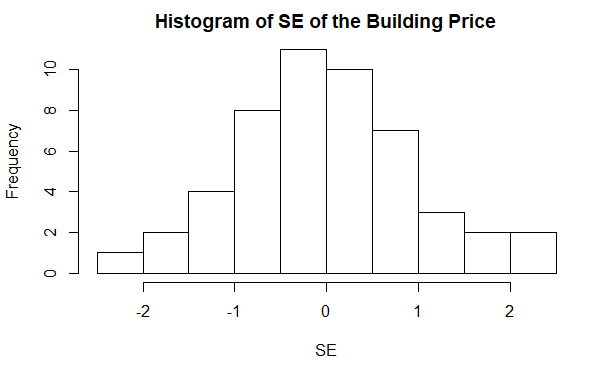

`r`r cat(# # # # The Normality Test # # # ,\n)

```
# # # # The Normality Test # # #
```

`r`r norm_test <- shapiro.test(SE) print(norm_test)

```
    Shapiro-Wilk normality test

data:  SE
W = 0.98456, p-value = 0.7527
```

```
Because p_value = 0.7527 > 0.05, do not rejected H0. We can assume that errors are normally distributed.
```

### b

```
Hypothesis:
```

$$H_0:Homoscedasticity\\
H_1:Heteroscedasticity$$

```
Scatter plot:
```

`r`r data1 <- read.csv(16-07.csv,header = 1) Floor <- data1$Floor Price <- data1$Price SE <- standarized_errors(Price, Floor)[ ,1] n <- length(Price) linearModelVar <- lm(Price ~ Floor) a <- coef(linearModelVar)1 b <- coef(linearModelVar)2 Price_p <- vector(, length = n) for(i in 1:n) { Price_p[i] <- a + b * Floor[i] } plot(x = Price_p,y = SE, xlab = Price, ylab = Error, main = Price vs Standard Errors)

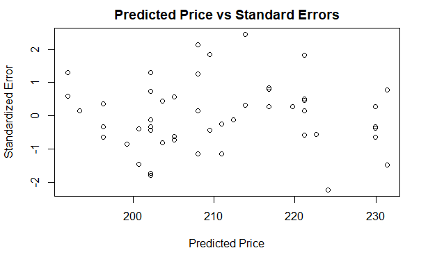

```
Conclusion:
Do not rejected H0. We can assume that the variation is constant and the mean is around 0.
Heteroscedasticity is NOT a problem.
```

### Detect the outliers and influential obs:

`r`r SE <- standarized_errors(Price, Floor)[ ,1] cat(# # # # Outliers # # # ,\n)

```
# # # # Outliers # # #
```

`r`r Outliers <- abs(SE) > 2 print(Outliers)

```
 [1] FALSE FALSE  TRUE FALSE FALSE FALSE FALSE FALSE FALSE FALSE FALSE FALSE FALSE FALSE FALSE FALSE FALSE FALSE FALSE FALSE  TRUE FALSE FALSE FALSE FALSE FALSE FALSE
[28] FALSE FALSE FALSE FALSE FALSE FALSE FALSE FALSE FALSE FALSE FALSE FALSE FALSE FALSE FALSE FALSE FALSE FALSE FALSE FALSE FALSE FALSE  TRUE
```

`r`r h <- standarized_errors(Price, Floor)[,2] cat(# # # # Influential Observations # # # ,\n)

```
# # # # Influential Observations # # #
```

`r`r n <- length(Price) Inf_Obs <- h > 6/n print(Inf_Obs)

```
 [1] FALSE FALSE FALSE FALSE FALSE FALSE FALSE FALSE FALSE FALSE FALSE FALSE FALSE FALSE FALSE FALSE FALSE FALSE FALSE FALSE FALSE FALSE FALSE FALSE FALSE FALSE FALSE
[28] FALSE FALSE FALSE FALSE FALSE FALSE FALSE FALSE FALSE FALSE FALSE FALSE FALSE FALSE FALSE FALSE FALSE FALSE FALSE FALSE FALSE FALSE FALSE
```

[output not shown]

## 16.125

```
Do the residual analysis for 16.13:
```

### 1

```
Normally Test:
Hypothesis:
```

$$H_0:Errors\ are\ normally\ distributed.\\
H_1:Errors\ are\ not\ normally\ distributed.$$

```
Apply the Shapiro-Wilks test of normality.
```

`r`r data2 <- read.csv(16-13.csv,header = 1) hours <- data2$Hours price <- data2$Price standarized_errors <- function(y, x) { n <- length(y) linearModelVar <- lm(y ~ x) a <- coef(linearModelVar)1 b <- coef(linearModelVar)2 se <- sigma(linearModelVar) x_mean <- mean(x) x_var <- var(x) h <- vector(, length = n) y_p <- vector(, length = n) Error <- vector(, length = n) Standard_E <- vector(, length = n) for(i in 1:n) { h[i] <- (1/n) + (x[i] - x_mean)^2 / (x_var * (n - 1)) y_p[i] <- a + b * x[i] Error[i] <- y[i] - y_p[i] Standard_E[i] <- Error[i] / (se * sqrt(1 - h[i])) } SEh <-cbind(Standard_E,h) return(SEh) } SE <- standarized_errors(price, hours)[ ,1] hist(SE,main = of SE of the Boat Price)

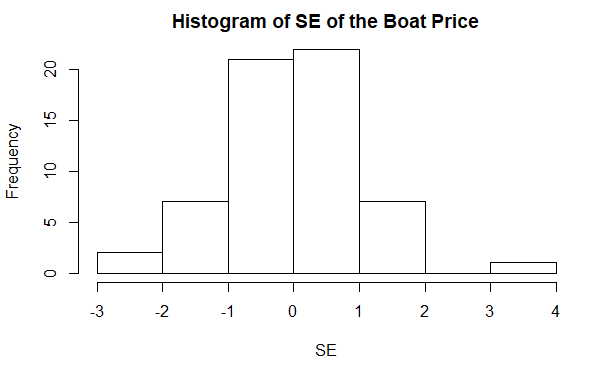

`r`r cat(# # # # The Normality Test # # # ,\n)

```
# # # # The Normality Test # # #
```

`r`r norm_test <- shapiro.test(SE) print(norm_test)

```
    Shapiro-Wilk normality test

data:  SE
W = 0.99, p-value = 0.9057
```

```
Because p_value = 0.9057 > 0.05, do not rejected H0. We can assume that errors are normally distributed.
```

### 2

```
Homoscedasticity or Heteroscedasticity:
Hypothesis:
```

$$H_0:Homoscedasticity\\
H_1:Heteroscedasticity$$

```
Scatter plot:
```

`r`r SE <- standarized_errors(price, hours)[ ,1] n <- length(price) linearModelVar <- lm(price ~ hours) a <- coef(linearModelVar)1 b <- coef(linearModelVar)2 Price_p <- vector(, length = n) for(i in 1:n) { Price_p[i] <- a + b * hours[i] } plot(x = Price_p,y = SE, xlab = Price, ylab = Error, main = Price vs Standard Errors)

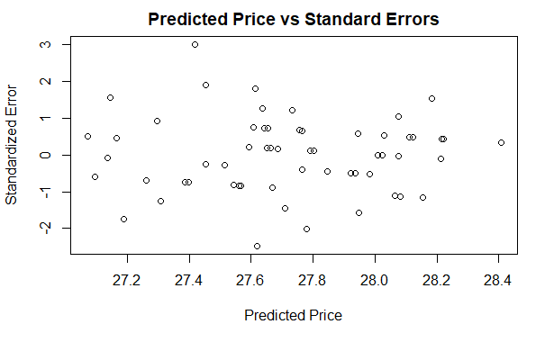

`r`r #SP <- scatter_plot(price, hours)[ ,1]

```
Conclusion:
Do not reject H0. We can assume that the variation is constant and the mean is around 0.
```

### 3

```
Dependence of the Error Variable:
Hypothesis:
```

$$H_0:\ Randomness\ exists.\\
H_1:\ Randomness\ does\ not\ exist.$$

`r`r library(randtests) SE <- standarized_errors(price, hours)[ ,1] Run_T <- runs.test(SE) print(Run_T)

```
    Runs Test

data:  SE
statistic = 1.0417, runs = 35, n1 = 30, n2 = 30, n = 60, p-value = 0.2976
alternative hypothesis: nonrandomness
```

```
Conclusion:
Because p-value = 0.2976 > 0.05, Do not reject H0.
There is no evidence to infer that the sample is not random.
```

### Conclusion

```
All the required conditions are satisfied.
```

### Detect the outliers and influential obs:

`r`r SE <- standarized_errors(price, hours)[ ,1] cat(# # # # Outliers # # # ,\n)

```
# # # # Outliers # # #
```

`r`r Outliers <- abs(SE) > 2 print(Outliers)

```
 [1] FALSE FALSE FALSE FALSE FALSE FALSE FALSE FALSE FALSE FALSE FALSE FALSE FALSE FALSE FALSE FALSE FALSE  TRUE FALSE FALSE FALSE FALSE FALSE FALSE  TRUE FALSE FALSE
[28] FALSE FALSE FALSE FALSE FALSE  TRUE FALSE FALSE FALSE FALSE FALSE FALSE FALSE FALSE FALSE FALSE FALSE FALSE FALSE FALSE FALSE FALSE FALSE FALSE FALSE FALSE FALSE
[55] FALSE FALSE FALSE FALSE FALSE FALSE
```

`r`r h <- standarized_errors(price, hours)[,2] cat(# # # # Influential Observations # # # ,\n)

```
# # # # Influential Observations # # #
```

`r`r n <- length(price) Inf_Obs <- h > 6/n print(Inf_Obs)

```
 [1] FALSE FALSE FALSE FALSE FALSE FALSE FALSE FALSE FALSE FALSE FALSE FALSE FALSE FALSE FALSE FALSE FALSE FALSE FALSE FALSE FALSE FALSE FALSE FALSE FALSE FALSE FALSE
[28] FALSE FALSE FALSE FALSE FALSE FALSE FALSE FALSE FALSE FALSE FALSE FALSE FALSE FALSE FALSE FALSE FALSE FALSE FALSE FALSE FALSE FALSE FALSE FALSE FALSE FALSE FALSE
[55] FALSE FALSE FALSE FALSE FALSE FALSE
```

```
Conclusion:
Samples 18, 25, 33 are outliers because their standardized residuals are larger than 2 or smaller than –2.
None of the samples is influential observation because none of their h is larger than 6/(sample size) = 0.1.
```

## 16.137

```
Use the steps of simple linear regression:
```

### 1

```
Plot the scatter diagram:
```

`r`r data4 <- read.csv(16-137.csv,header = 1) Fund <- data4$Fund Gold <- data4$Gold plot(Fund,Gold,col=,main = Fund against Gold Price,xlab=Price,ylab=of Fund) abline(lm(Fund~Gold))

[figure not shown]

### 2

```
Propose a statistical model:
```

$$y\ =\ \beta_0\ +\ \beta_1x\ +\ \varepsilon$$
y = the value of fund

x = the gold price

$\varepsilon$ = error variable

### 3

```
Fit the model:
```

`r`r linearModelVar <- lm(Fund ~ Gold) a <- coef(linearModelVar)1 b <- coef(linearModelVar)2 se <- sigma(linearModelVar) Gold_mean <- mean(Gold) Gold_var <- var(Gold) print(summary(linearModelVar))

```
Call:
lm(formula = Fund ~ Gold)

Residuals:
     Min       1Q   Median       3Q      Max
-1.05090 -0.36899 -0.04292  0.27311  1.76639

Coefficients:
             Estimate Std. Error t value Pr(>|t|)
(Intercept) -20.20931    4.81000  -4.202 0.000276 ***
Gold          0.08510    0.01283   6.635 4.89e-07 ***
---
Signif. codes:  0 <e2><98>***<e2><99> 0.001 <e2><98>**<e2><99> 0.01 <e2><98>*<e2><99> 0.05 <e2><98>.<e2><99> 0.1 <e2><98> <e2><99> 1

Residual standard error: 0.5575 on 26 degrees of freedom
Multiple R-squared:  0.6287,    Adjusted R-squared:  0.6144
F-statistic: 44.02 on 1 and 26 DF,  p-value: 4.885e-07
```

```
From above, we can tell the regression line:
```

$$\hat{y}\ =\ -20.20931\ +\ 0.08510 x$$

### 4

```
Residual analysis:
```

1. Standardizing Residuals

`r`r standarized_errors <- function(y, x) { n <- length(y) linearModelVar <- lm(y ~ x) a <- coef(linearModelVar)1 b <- coef(linearModelVar)2 se <- sigma(linearModelVar) x_mean <- mean(x) x_var <- var(x) h <- vector(, length = n) y_p <- vector(, length = n) Error <- vector(, length = n) Standard_E <- vector(, length = n) for(i in 1:n) { h[i] <- (1/n) + (x[i] - x_mean)^2 / (x_var * (n - 1)) y_p[i] <- a + b * x[i] Error[i] <- y[i] - y_p[i] Standard_E[i] <- Error[i] / (se * sqrt(1 - h[i])) } SEh <-cbind(Standard_E,h) return(SEh) } SE <- standarized_errors(Fund, Gold)[ ,1] print(SE)

```
 [1] -1.16030531 -0.46594183 -1.20783399 -0.39726865 -0.62918449
 [6] -0.29958320  1.11959213  3.31294724 -0.25207526  0.41451623
[11] -0.81135434  1.39537754 -0.47663304  0.21558608  0.50624777
[16]  0.71751309  0.25192552 -0.23345946  0.08536931  0.75453984
[21] -1.02060994  0.31015855 -0.88276173  0.44341446  0.49719511
[26] -0.87277265  0.72974829 -2.09001240
```

2. Detect outliers and influential obs

`r`r SE <- standarized_errors(Fund, Gold)[ ,1] cat(# # # # Outliers # # # ,\n)

```
# # # # Outliers # # #
```

`r`r Outliers <- abs(SE) > 2 print(Outliers)

```
 [1] FALSE FALSE FALSE FALSE FALSE FALSE FALSE  TRUE FALSE FALSE FALSE
[12] FALSE FALSE FALSE FALSE FALSE FALSE FALSE FALSE FALSE FALSE FALSE
[23] FALSE FALSE FALSE FALSE FALSE  TRUE
```

`r`r h <- standarized_errors(Fund, Gold)[,2] cat(# # # # Influential Observations # # # ,\n)

```
# # # # Influential Observations # # #
```

`r`r n <- length(Gold) Inf_Obs <- h > 6/n print(Inf_Obs)

```
 [1] FALSE FALSE FALSE FALSE FALSE FALSE FALSE FALSE FALSE FALSE FALSE
[12] FALSE FALSE FALSE FALSE FALSE FALSE FALSE  TRUE FALSE FALSE FALSE
[23] FALSE FALSE FALSE FALSE FALSE FALSE
```

```
Conclusion:
Sample 8, 28 are outliers because their standardized residuals are larger than 2 or smaller than –2.
Sample 19 is an influential observation because its h is larger than 6/(sample size).
```

3. Normality Test

   Hypothesis:

$$H_0:Errors\ are\ normally\ distributed.\\
H_1:Errors\ are\ not\ normally\ distributed.$$

```
Apply the Shapiro-Wilks test of normality.
```

`r`r SE <- standarized_errors(Fund, Gold)[ ,1] hist(SE,main = of SE of the Gold Price)

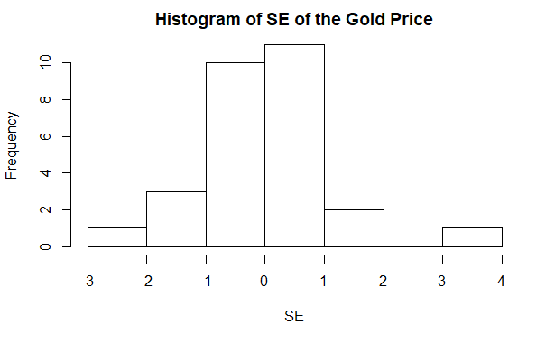

`r`r cat(# # # # The Normality Test # # # ,\n)

```
# # # # The Normality Test # # #
```

`r`r norm_test <- shapiro.test(SE) print(norm_test)

```
    Shapiro-Wilk normality test

data:  SE
W = 0.93574, p-value = 0.08612
```

```
Because p_value = 0.08612 > 0.05, we do not rejected H0. We can NOT infer that errors are not normally distributed.
```

4. Homoscedasticity or Heteroscedasticity:

   Hypothesis:

$$H_0:Homoscedasticity\\
H_1:Heteroscedasticity$$

```
Scatter plot:
```

`r`r SE <- standarized_errors(Fund, Gold)[ ,1] n <- length(Fund) linearModelVar <- lm(Fund ~ Gold) a <- coef(linearModelVar)1 b <- coef(linearModelVar)2 Price_p <- vector(, length = n) for(i in 1:n) { Price_p[i] <- a + b * Gold[i] } plot(x = Price_p,y = SE, xlab = Fund, ylab = Error, main = Fund vs Standard Errors)

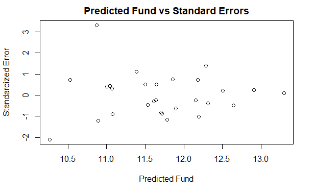

```
Conclusion:
Do not Rejected H0. We can assume that the variation is constant and the mean is around 0.
```

5. Dependence of the Error Variable:

   Hypothesis:

$$H_0:\ Randomness\ exists.\\
H_1:\ Randomness\ does\ not\ exist.$$

`r`r library(randtests) SE <- standarized_errors(Fund, Gold)[ ,1] Run_T <- runs.test(SE) print(Run_T)

```
    Runs Test

data:  SE
statistic = 0.77033, runs = 17, n1 = 14, n2 = 14, n = 28,
p-value = 0.4411
alternative hypothesis: nonrandomness
```

```
Conclusion:
When n1=14 and n2=14 (both less than 20), the lower bound k1=9 and the upper bound k2=21 (according to the table in the Powerpoint).
Since k1=9<Runs=17<k2=21, we don’t reject H0.
We can not infer that randomness doesn’t exist.
```

### 5

```
Assess the fitted model:
```

1. Standard Error of Estimate.

`r`r linearModelVar <- lm(Fund ~ Gold) a <- coef(linearModelVar)1 b <- coef(linearModelVar)2 se <- sigma(linearModelVar) Gold_mean <- mean(Gold) Gold_var <- var(Gold) print(summary(linearModelVar))

```
Call:
lm(formula = Fund ~ Gold)

Residuals:
     Min       1Q   Median       3Q      Max
-1.05090 -0.36899 -0.04292  0.27311  1.76639

Coefficients:
             Estimate Std. Error t value Pr(>|t|)
(Intercept) -20.20931    4.81000  -4.202 0.000276 ***
Gold          0.08510    0.01283   6.635 4.89e-07 ***
---
Signif. codes:  0 <e2><98>***<e2><99> 0.001 <e2><98>**<e2><99> 0.01 <e2><98>*<e2><99> 0.05 <e2><98>.<e2><99> 0.1 <e2><98> <e2><99> 1

Residual standard error: 0.5575 on 26 degrees of freedom
Multiple R-squared:  0.6287,    Adjusted R-squared:  0.6144
F-statistic: 44.02 on 1 and 26 DF,  p-value: 4.885e-07
```

`r`r cat(of y = ,mean(Fund))

```
mean of y =  11.69714
```

```
Conclusion:
```

Judge the value of ${\sigma}_{\varepsilon}$ = 0.5575 by comparing it to the sample mean of the dependent variable (y = 11.69714).

So (relatively speaking) it appears to be small, hence our linear regression model of the value of fund as a function of gold price is “good”.

b.Using descriptive measurements, $r^2$ and r.

`r`r linearModelVar <- lm(Fund ~ Gold) coe_corr <- cor(Fund,Gold) rsquared <- summary(linearModelVar)$r.squared cat(# # # # The Coefficient of determination # # # ,\n)

```
# # # # The Coefficient of determination # # #
```

`r`r print(rsquared)

```
[1] 0.628691
```

`r`r cat(# # # # The Coefficient of coefficient # # # ,\n)

```
# # # # The Coefficient of coefficient # # #
```

`r`r print(coe_corr)

```
[1] 0.7929004
```

`r`r cat(# # # # The regression model # # # ,\n)

```
# # # # The regression model # # #
```

`r`r print(summary(linearModelVar))

```
Call:
lm(formula = Fund ~ Gold)

Residuals:
     Min       1Q   Median       3Q      Max
-1.05090 -0.36899 -0.04292  0.27311  1.76639

Coefficients:
             Estimate Std. Error t value Pr(>|t|)
(Intercept) -20.20931    4.81000  -4.202 0.000276 ***
Gold          0.08510    0.01283   6.635 4.89e-07 ***
---
Signif. codes:  0 <e2><98>***<e2><99> 0.001 <e2><98>**<e2><99> 0.01 <e2><98>*<e2><99> 0.05 <e2><98>.<e2><99> 0.1 <e2><98> <e2><99> 1

Residual standard error: 0.5575 on 26 degrees of freedom
Multiple R-squared:  0.6287,    Adjusted R-squared:  0.6144
F-statistic: 44.02 on 1 and 26 DF,  p-value: 4.885e-07
```

$r^2$ = 0.6287

[output not shown]

`r`r r = sqrt(0.6287) cat(= ,+r)

```
r =  0.792906
```

```
There is a very strong positive linear relationship (about 79.29%) between the price of the gold and the fund.
```

3. Testing and/or estimating the coefficients.

   Hypothesis testing about Beta1:

$$H_0:\beta_1\ =\ 0\\
H_1:\beta_1\ >\ 0$$

```
We use t-Test to check if H0 is to be rejected or not.
```

`r`r linearModelVar <- lm(Fund ~ Gold) a <- coef(linearModelVar)1 b <- coef(linearModelVar)2 se <- sigma(linearModelVar) Gold_mean <- mean(Gold) Gold_var <- var(Gold) print(summary(linearModelVar))

```
Call:
lm(formula = Fund ~ Gold)

Residuals:
     Min       1Q   Median       3Q      Max
-1.05090 -0.36899 -0.04292  0.27311  1.76639

Coefficients:
             Estimate Std. Error t value Pr(>|t|)
(Intercept) -20.20931    4.81000  -4.202 0.000276 ***
Gold          0.08510    0.01283   6.635 4.89e-07 ***
---
Signif. codes:  0 <e2><98>***<e2><99> 0.001 <e2><98>**<e2><99> 0.01 <e2><98>*<e2><99> 0.05 <e2><98>.<e2><99> 0.1 <e2><98> <e2><99> 1

Residual standard error: 0.5575 on 26 degrees of freedom
Multiple R-squared:  0.6287,    Adjusted R-squared:  0.6144
F-statistic: 44.02 on 1 and 26 DF,  p-value: 4.885e-07
```

```
Because we are doing right-tail test, p-value = 4.89e-07/2 = 2.45e-07
Since p-value = 2.45e-07 < 0.05, we reject H0.
We conclude that the relationship between x and y is significant.
-
Use the t-test of the coefficient of correlation to determine if there is a positive linear relationship between the value of the fund and the price of gold.
Hypothesis:
```

$$H_0:\rho\ =\ 0\\
H_1:\rho\ \neq\ 0$$

`r`r data4 <- read.csv(16-137.csv,header = 1) Fund <- data4$Fund Gold <- data4$Gold test_cor <- cor.test(Fund, Gold,alternative = .sided) cat(# # # # The test of Coefficient of Correlation # # # ,\n)

```
# # # # The test of Coefficient of Correlation # # #
```

`r`r print(test_cor)

```
    Pearson's product-moment correlation

data:  Fund and Gold
t = 6.6349, df = 26, p-value = 4.885e-07
alternative hypothesis: true correlation is not equal to 0
95 percent confidence interval:
 0.5961816 0.8998038
sample estimates:
      cor
0.7929004
```

```
Since p-value = 4.885e-07 < 0.05, we reject H0.
There is sufficient evidence at a = 5% to infer that there is a  positive linear relationship between the two variables.
```

### 6

```
Interpretation:
```

$$\hat{y}\ =\ b_0\ +\ b_1x\ =\ -20.20931\ +\ 0.08510 x$$

### 7

```
Apply for prediction:
(1)Predict with 95% confidence the value of fund with gold of 370 dollars.
Use prediction interval:
```

`r`r linearModelVar <- lm(Fund ~ Gold) cat(# # # # The prediction interval # # # ,\n)

```
# # # # The prediction interval # # #
```

`r`r newdata = data.frame(Gold=370) PI <- predict(linearModelVar, newdata, interval=) print(PI)

```
       fit      lwr      upr
1 11.27697 10.10353 12.45042
```

```
There is 95% chance that the interval [10.10353, 12.45042] will cover the real value of fund with gold of 370 dollars.

(2) Estimate with 95% confidence the average fund price with gold of 370 dollars.
Use confidence interval:
```

`r`r cat(# # # # The confidence interval # # # ,\n)

```
# # # # The confidence interval # # #
```

`r`r newdata = data.frame(Gold=370) CI <- predict(linearModelVar, newdata, interval=) print(CI)

```
       fit     lwr      upr
1 11.27697 11.0243 11.52964
```

```
There is 95% chance that the interval [ 11.0243, 11.52964] will cover the real average fund price with gold of 370 dollars.
```

### Conclusion:

```
We can infer that there is a positive linear relationship between the value of the fund and the price of gold.
```